```python
import pandas as pd
import seaborn as sns
from datetime import datetime, date
from sklearn.preprocessing import OneHotEncoder, LabelEncoder, MinMaxScaler
from sklearn.model_selection import train_test_split
from sklearn.linear_model import LogisticRegression
from sklearn.metrics import accuracy_score, confusion_matrix
from sklearn.ensemble import GradientBoostingClassifier, VotingClassifier, RandomForestClassifier
from sklearn.neighbors import KNeighborsClassifier
from sklearn.metrics import plot_confusion_matrix
from src.useful_func import do_everything, create_voting_classifier, create_graph
import matplotlib.pyplot as plt
import numpy as np
```

# Predicting Water Well Pump Functionality in Tanzania

## Key Results

Easy access to safe drinking water is paramount to the health and success of communities. In order to efficiently use limited resources for updating, repairing, and installing water well pumps in communities across Tanzania, we develop a classification model for predicting the functionality status of pumps based on features of the well. Using a consensus method of 4 independent classification models, we achieve ~82% accuracy on the test data. Additionally, we report highly correlated features of well functionality, which can be used in deciding what features are most important to retaining functional wells in the long term.

The Python code that is implemented in this notebook reproduces our findings with an emphasis on evaluating the models.

## Data Source and Processing

We downloaded data collected by Tariifa from [drivendata.org](https://www.drivendata.org/competitions/7/pump-it-up-data-mining-the-water-table/page/23/), which was aggregated from the Tanzanian Ministry of Water. The data consist of over 50,000 records of water well pumps across the country, including various features about the wells, such as install date, pump type, etc, and their functionality status.

The following cell prepares the data for modeling by importing from .csv files and moving data into a Pandas DataFrame. In addition, it drops a number of inconsequential features from the dataset, reformats dates to reflect time passed, deals with missing data, and encodes categorical variables using one-hot encoding. Finally, it will perform a train-test split on the data (95/5) and return the processed DataFrame with target values.

```python
string_1 = 'data/training_data_values.csv' #Your filepath to the data here
string_2 = 'data/training_data_labels.csv' #Your filepath to the data here
drop_columns = ['id', 'funder', 'num_private', 'longitude', 'latitude', 'wpt_name', 'subvillage', 'region_code', 'lga',
                'ward','recorded_by', 'scheme_name', 'extraction_type_group', 'payment', 'quality_group',
                'quantity_group', 'source_type', 'source_class', 'waterpoint_type_group']


X_train, X_test, y_train, y_test, df_values, df_target = do_everything(string_1, string_2, drop_columns)
```

## Data Modeling

We tested 4 different machine learning classification models: Logistic Regression, K-Nearest Neighbor, Random Forest, and Gradient Boosted Forest. Individually, these models perform well on the test data, about 80% accuracy. However, to decrease the impacts of potential biases from the individual models, we combine the four models using a Soft Voting Classifier. This consensus method takes predictions from the individual models, weights them by their certainty, and returns the prediction with the most "votes."

The following cell trains the 4 models, combines them with the Soft Voting Classifier, and returns a normalized confusion matrix of the performance on the test data. The total accuracy for the classifier is about 82%, slightly higher than individual models. The model performs well at predicting both the "functional" and "nonfunctional" classes, however it struggles with the "functional but needs repair" class, which is the smallest class and is underrepresented in the training data.

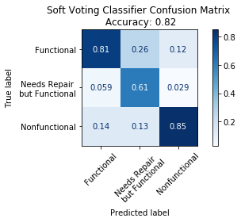

```python
eclf, score = create_voting_classifier(X_train, X_test, y_train, y_test)
```

## Further Considerations

To explore potential explanatory factors for well functionality, we also calculated correlation values for each feature in the dataset. In the following graph, we show the ten most positively and negatively correlated features. Many of these features are related to water availability, region, or how the well is operated (e.g., paid or free access) and thus are not relevant to the pump itself. We find that simple well pumps such as hand-pumps and gravity-pumps have a positive correlation with functioning, and thus may represent better investments for long term usage.

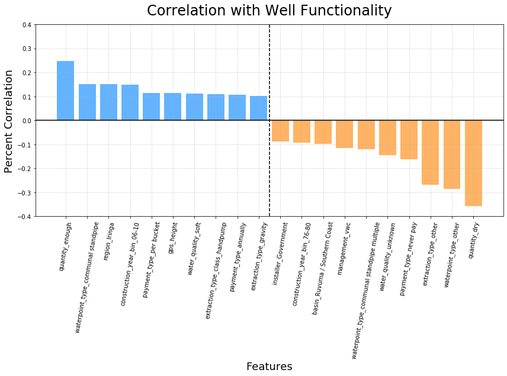

```python
create_graph(df_target, df_values)
```

## Future Directions

Given more time for this project, we suggest improving the model and investigating well functionality further in the following ways:

1. Address class imbalances to better identify wells that need repair but are still functioning
2. Add functionality to prioritize wells in more populous areas or areas without other water sources
3. Further investigate features that correlate specifically with pump failings and not just overall well functionality